# Lecture Code: Regression Inference

Engineering Statistics I (MA223)

## Background

When purchasing or selling a home, your real estate agent helps you determine if a house is priced correctly. This involves comparing the price of the home with its “comparables” (similar homes in the area) to determine if the price is similar. One method for doing this is to use a model which has been built to predict the price of a home given its characteristics. We have data on over 500 sales regarding the sale price and various characteristics of the home. The data consists of the following variables (and the first few records are shown below):

- ID: unique identification for each sale.
- Price: Sale price of home ($).
- SqFeet: Finished area of residence (square feet).
- BedRooms: Number of bedrooms in residence.
- BathRooms: Number of bathrooms in residence.
- AC: Indicator of whether home has central air conditioning (1 = Yes, 0 = No).
- Garage: Number of cars that garage will hold.
- Pool: Indicator of whether home has a simming pool (1 = Yes, 0 = No).
- Year: Year property was originally constructed.
- Quality: Indicator of quality construction (1 = High quality, 2 = Medium, 3 = Low).
- Style: Indicator of arhitectural style.
- Lot: Lot size (square feet).
- Highway: Indicator of whether home is located near highway (1 = Yes, 0 = No).

```
## # A tibble: 522 x 13
##       ID  Price SqFeet BedRooms BathRooms    AC Garage  Pool  Year Quality
##    <int>  <int>  <int>    <int>     <int> <int>  <int> <int> <int>   <int>
##  1     1 360000   3032        4         4     1      2     0  1972       2
##  2     2 340000   2058        4         2     1      2     0  1976       2
##  3     3 250000   1780        4         3     1      2     0  1980       2
##  4     4 205500   1638        4         2     1      2     0  1963       2
##  5     5 275500   2196        4         3     1      2     0  1968       2
##  6     6 248000   1966        4         3     1      5     1  1972       2
##  7     7 229900   2216        3         2     1      2     0  1972       2
##  8     8 150000   1597        2         1     1      1     0  1955       2
##  9     9 195000   1622        3         2     1      2     0  1975       3
## 10    10 160000   1976        3         3     0      1     0  1918       3
## # ... with 512 more rows, and 3 more variables: Style <int>, Lot <int>,
## #   Highway <int>
```

For the purposes of today, let’s consider the following question of interest:

> We know that larger homes tend to fetch a higher price. However, is this relationship similar in homes with a pool as homes without a pool?

```r
# Clean Data
realestate <- realestate %>%
  mutate(AC = recode(AC,
                     `0` = "No A/C",
                     `1` = "Has A/C"),
         Garage = factor(Garage),
         Pool = recode(Pool,
                       `0` = "No Pool",
                       `1` = "Pool"),
         Quality = recode(Quality,
                          `1` = "High",
                          `2` = "Medium",
                          `3` = "Low"),
         Highway = recode(Highway,
                          `0` = "No",
                          `1` = "Yes"))
```

## Graphical Summary

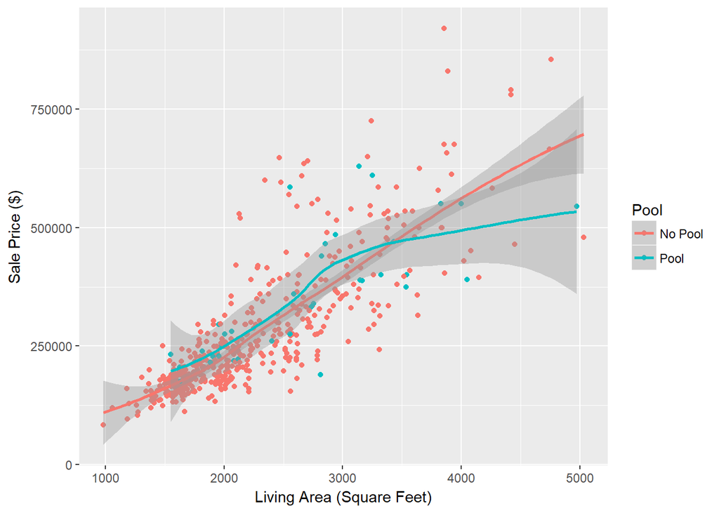

A model with an interaction term includes the product of two predictors. It allows the effect of one of the variables to depend on the other.

$$(\text{Price})_i = \beta_0 + \beta_1(\text{Area})_i + \beta_2\mathbb{I}(\text{i-th home has Pool}) + \beta_3(\text{Area})_i \mathbb{I}(\text{i-th home has Pool}) + \epsilon_i$$

## Conclusion

We fit the products using the colon (`:`) in the model statement.

```r
fit <- lm(Price ~ SqFeet + Pool + SqFeet:Pool, data = realestate)
tidy(fit, conf.int = TRUE)
```

```
##              term     estimate    std.error statistic       p.value
## 1     (Intercept) -88538.99588 12063.236626 -7.339572  8.344289e-13
## 2          SqFeet    161.91024     5.167794 31.330630 1.172977e-121
## 3        PoolPool 105909.97162 47262.734656  2.240877  2.545698e-02
## 4 SqFeet:PoolPool    -37.21317    17.102217 -2.175926  3.001199e-02
##       conf.low     conf.high
## 1 -112237.8780 -64840.113751
## 2     151.7578    172.062655
## 3   13059.7679 198760.175305
## 4     -70.8114     -3.614935
```